# battle_clear-clear-data-checks

Inigo Peng, edited by Badhia Yunes-Katz

2025-07-16

# Database Tables

## battle_clear

### catch

**- Findings catch:**

- a lot of “not provided” values on EDI lifestage. Since DB has not been wrangled it is hard to compare. Flagging this in case we cant to look into details

#### Date Range Check

*EDI `date`*

```r
range(catch_battle_clear_edi$date)
```

```
## [1] "1998-10-09" "2025-06-24"
```

*DB `date`*

```
## [1] "1998-10-09" "2025-06-24"
```

#### ForkLength

*EDI `fork_length`*

- 0.1 % of values in the `fork_length` column are NA.

```
##    Min. 1st Qu.  Median    Mean 3rd Qu.    Max.    NA's
##    0.00   34.00   36.00   38.78   38.00  232.00     369
```

*DB `fork_length`*

- 0.1 % of values in the `fork_length` column are NA.

```
##    Min. 1st Qu.  Median    Mean 3rd Qu.    Max.    NA's
##    0.00   34.00   36.00   38.78   38.00  232.00     369
```

*Forklength Exploration Plots*

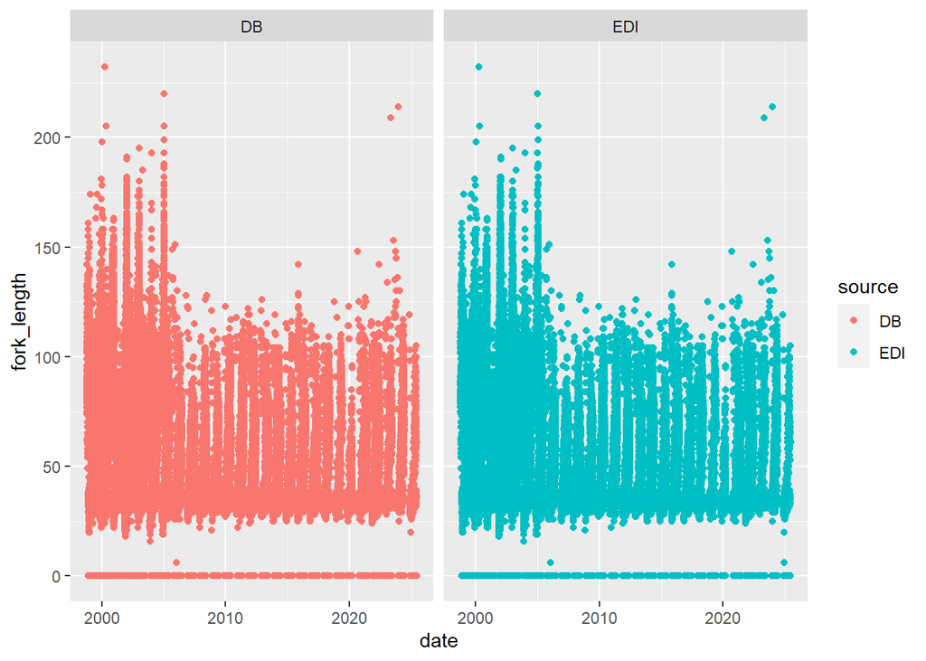

#### Lifestage

(life stage in edi data has not gone through wrangling)

*EDI `life_stage`*

- 0 % of values in the `life_stage` column from the EDI data are NA.

*DB `lifestage_id`*

- 0 % of values in the `lifestage_id` column from the database are NA.

#### Count

*EDI `count`*

- 0.1 % of values in the `count` column in edi data are NA.

```
##     Min.  1st Qu.   Median     Mean  3rd Qu.     Max.     NA's
##     0.00     1.00     1.00    19.53     1.00 84426.00      631
```

*DB `count`*

- 0.1 % of values in the `count` column in database data are NA.

```
##     Min.  1st Qu.   Median     Mean  3rd Qu.     Max.     NA's
##     0.00     1.00     1.00    19.53     1.00 84426.00      630
```

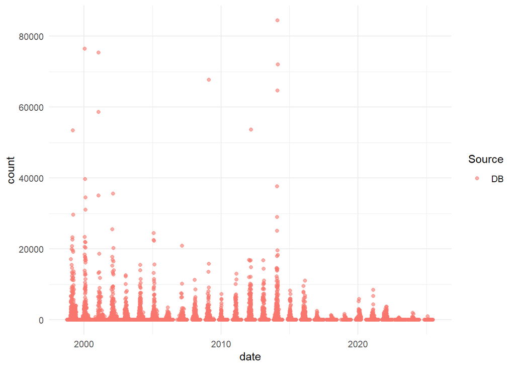

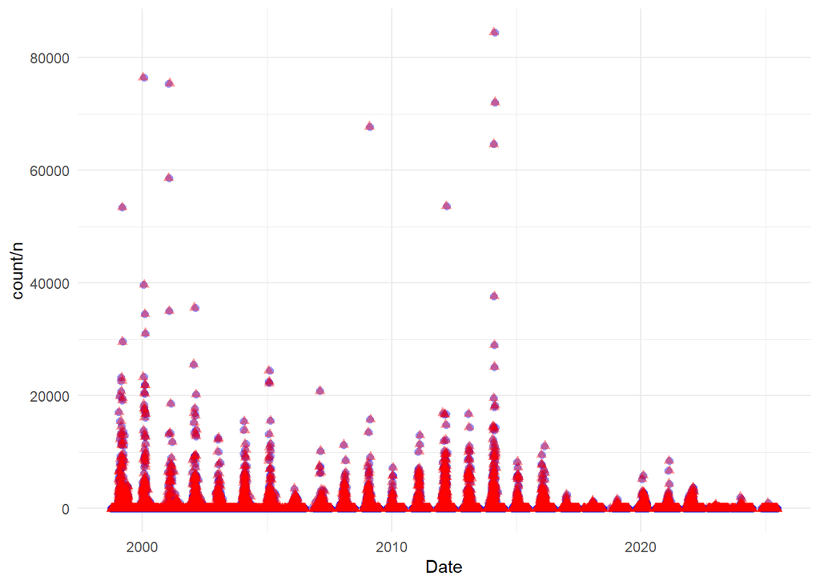

Random pick of data entry to compare between db and EDI

- test 1

```
## Rows: 1
## Columns: 17
## $ id               <int> 4738138
## $ catch_raw_id     <chr> "{292A0C58-FB5F-11D4-B974006008C01BCF}"
## $ trap_location_id <int> 14
## $ date             <date> 1999-01-17
## $ count            <dbl> 15
## $ run_id           <int> 3
## $ lifestage_id     <int> 4
## $ adipose_clipped  <lgl> FALSE
## $ dead             <lgl> NA
## $ fork_length      <dbl> 36
## $ weight           <dbl> 0
## $ actual_count     <lgl> NA
## $ updated_at       <dttm> 2025-07-14 09:03:10
## $ stream           <chr> "clear creek"
## $ site             <chr> "lcc"
## $ subsite          <chr> NA
## $ source           <chr> "DB"
```

```
## Rows: 1
## Columns: 17
## $ catch_row_id <chr> "{292A0C58-FB5F-11D4-B974006008C01BCF}"
## $ sample_id    <chr> "017_99"
## $ sample_date  <date> 1999-01-17
## $ station_code <chr> "lower clear creek"
## $ count        <dbl> 15
## $ r_catch      <dbl> 15
## $ fork_length  <dbl> 36
## $ weight       <dbl> 0
## $ fws_run      <chr> "fall"
## $ interp       <lgl> FALSE
## $ brood_year   <dbl> 1998
## $ subsample    <chr> NA
## $ common_name  <chr> "Chinook Salmon"
## $ life_stage   <chr> "not provided"
## $ stream       <chr> "battle clear creek"
## $ date         <date> 1999-01-17
## $ source       <chr> "EDI"
```

- test 2

```
## Rows: 1
## Columns: 17
## $ id               <int> 4738639
## $ catch_raw_id     <chr> "{2929F03F-FB5F-11D4-B974006008C01BCF}"
## $ trap_location_id <int> 14
## $ date             <date> 1999-03-09
## $ count            <dbl> 1
## $ run_id           <int> 3
## $ lifestage_id     <int> 4
## $ adipose_clipped  <lgl> FALSE
## $ dead             <lgl> NA
## $ fork_length      <dbl> 38
## $ weight           <dbl> 0
## $ actual_count     <lgl> NA
## $ updated_at       <dttm> 2025-07-14 09:03:10
## $ stream           <chr> "clear creek"
## $ site             <chr> "lcc"
## $ subsite          <chr> NA
## $ source           <chr> "DB"
```

```
## Rows: 1
## Columns: 17
## $ catch_row_id <chr> "{2929F03F-FB5F-11D4-B974006008C01BCF}"
## $ sample_id    <chr> "068_99"
## $ sample_date  <date> 1999-03-09
## $ station_code <chr> "lower clear creek"
## $ count        <dbl> 1
## $ r_catch      <dbl> 1
## $ fork_length  <dbl> 38
## $ weight       <dbl> 0
## $ fws_run      <chr> "fall"
## $ interp       <lgl> FALSE
## $ brood_year   <dbl> 1998
## $ subsample    <chr> NA
## $ common_name  <chr> "Chinook Salmon"
## $ life_stage   <chr> "not provided"
## $ stream       <chr> "battle clear creek"
## $ date         <date> 1999-03-09
## $ source       <chr> "EDI"
```

- test 3

```
## Rows: 1
## Columns: 17
## $ id               <int> 4741339
## $ catch_raw_id     <chr> "{4B85B5E1-9066-496A-A7F52185657FBFDE}"
## $ trap_location_id <int> 14
## $ date             <date> 2013-01-07
## $ count            <dbl> 1
## $ run_id           <int> 3
## $ lifestage_id     <int> 2
## $ adipose_clipped  <lgl> FALSE
## $ dead             <lgl> NA
## $ fork_length      <dbl> 37
## $ weight           <dbl> 0
## $ actual_count     <lgl> NA
## $ updated_at       <dttm> 2025-07-14 09:03:10
## $ stream           <chr> "clear creek"
## $ site             <chr> "lcc"
## $ subsite          <chr> NA
## $ source           <chr> "DB"
```

```
## Rows: 1
## Columns: 17
## $ catch_row_id <chr> "{4B85B5E1-9066-496A-A7F52185657FBFDE}"
## $ sample_id    <chr> "007_13"
## $ sample_date  <date> 2013-01-07
## $ station_code <chr> "lower clear creek"
## $ count        <dbl> 1
## $ r_catch      <dbl> 1
## $ fork_length  <dbl> 37
## $ weight       <dbl> 0
## $ fws_run      <chr> "fall"
## $ interp       <lgl> FALSE
## $ brood_year   <dbl> 2012
## $ subsample    <chr> NA
## $ common_name  <chr> "Chinook Salmon"
## $ life_stage   <chr> "obvious fry"
## $ stream       <chr> "battle clear creek"
## $ date         <date> 2013-01-07
## $ source       <chr> "EDI"
```

### Trap

**- Findings trap:**

```r
trap_battle_clear_edi <- read_csv("data-raw/edi-zips/battle_clear_trap.csv") |>
  mutate(stream="battle clear creek",
         date = as.Date(sample_date)) |>
  filter(!is.na(station_code)) |>
  arrange(trap_start_date) |>
  group_by(sample_id, station_code) |>
  slice_tail(n = 1)  |>
  ungroup()
```

#### Date Range Check

*DB `trap_visit_time_start`*

```
## [1] "1998-08-31 07:50:00 UTC" "2025-07-14 07:45:00 UTC"
```

*EDI `trap_start_date`*

```r
range(trap_battle_clear_edi$trap_start_date, na.rm = TRUE)
```

```
## [1] "1998-08-31" "2025-07-14"
```

#### water_velocity

*DB `water_velocity`*

- 16.9 % of values in the `water_velocity` column are NA.

```
##    Min. 1st Qu.  Median    Mean 3rd Qu.    Max.    NA's
##   0.000   2.100   2.600   3.278   3.350 483.450    3684
```

*EDI `velocity`*

- 16.9 % of values in the `velocity` column are NA.

```
##    Min. 1st Qu.  Median    Mean 3rd Qu.    Max.    NA's
##   0.000   2.100   2.600   3.278   3.350 483.450    3684
```

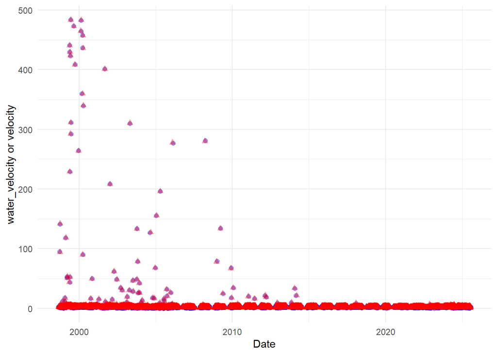

```r
trap_battle_clear_edi_clean<- trap_battle_clear_edi |>
  mutate(date = as.Date(sample_date),
         source = "EDI")
trap_battle_clear_db_clean <- trap_battle_clear_db |>
  mutate(date = as.Date(trap_visit_time_start),
         source = "DB")

ggplot() +
  geom_jitter(data = trap_battle_clear_db_clean,
              aes(x = date, y = water_velocity, color = source),
              color = "blue", alpha = 0.4, width = 10, height = 0.5, shape = 16, size = 2) +
  geom_jitter(data = trap_battle_clear_edi_clean,
              aes(x = date, y = velocity),
              color = "red", alpha = 0.4, width = 10, height = 0.5, shape = 17, size = 2) +
  theme_minimal() +
  labs(x = "Date",
       y = "water_velocity or velocity",
       color = "Source"
       )
```

#### debris tubs/volume

*DB `debris_volume`*

- 15.1 % of values in the `debris_volume` column are NA.

```
##    Min. 1st Qu.  Median    Mean 3rd Qu.    Max.    NA's
##       0       2       5      14      10   51420    3298
```

*EDI `debris_tubs`*

- 15.1 % of values in the `debris_tubs` column are NA.

```
##     Min.  1st Qu.   Median     Mean  3rd Qu.     Max.     NA's
##    0.000    0.200    0.500    1.401    1.000 5142.000     3295
```

Random pick of data entry to compare between db and EDI

- test 1

```
## Rows: 3
## Columns: 25
## $ id                         <int> 311523, 311524, 311525
## $ trap_location_id           <int> 14, 3, 2
## $ trap_visit_id              <chr> "277_99", "277_99", "277_99"
## $ visit_type_id              <int> NA, NA, NA
## $ trap_visit_time_start      <dttm> 1999-10-03 08:41:00, 1999-10-03 10:07:00, 1…
## $ trap_visit_time_end        <dttm> 1999-10-04 08:52:00, 1999-10-04 10:23:00, 1…
## $ trap_functioning_id        <int> 2, 2, 2
## $ in_half_cone_configuration <lgl> FALSE, NA, FALSE
## $ fish_processed_id          <int> NA, NA, NA
## $ rpm_start                  <dbl> 0.1166667, 0.1616667, 0.2166667
## $ rpm_end                    <dbl> NA, NA, NA
## $ total_revolutions          <dbl> 14028, 9073, 6653
## $ debris_volume              <dbl> 20, 6, 7
## $ debris_level_id            <int> NA, NA, NA
## $ discharge                  <dbl> 877000, 889000, 900000
## $ water_velocity             <dbl> 4.42, 2.59, 2.04
## $ water_temp                 <dbl> NA, NA, NA
## $ turbidity                  <dbl> 1.7, 2.2, 2.3
## $ include                    <lgl> NA, NA, NA
## $ updated_at                 <dttm> 2025-07-14 09:08:48, 2025-07-14 09:08:48, 2…
## $ updated_by                 <chr> "AdminJPE", "AdminJPE", "AdminJPE"
## $ stream                     <chr> "clear creek", "battle creek", "battle cree…
## $ site                       <chr> "lcc", "lbc", "ubc"
## $ subsite                    <chr> NA, "lbc", NA
## $ source                     <chr> "DB", "DB", "DB"
```

```
## Rows: 3
## Columns: 33
## $ sample_id          <chr> "277_99", "277_99", "277_99"
## $ sample_date        <date> 1999-10-04, 1999-10-04, 1999-10-04
## $ sample_time        <time> 10:23:00, 08:52:00, 11:10:00
## $ trap_start_date    <date> 1999-10-03, 1999-10-03, 1999-10-03
## $ trap_start_time    <time> 10:07:00, 08:41:00, 10:56:00
## $ station_code       <chr> "lower battle creek", "lower clear creek", "upper b…
## $ depth_adjust       <dbl> 28, 29, 27
## $ avg_time_per_rev   <dbl> 9.7, 7.0, 13.0
## $ flow_start_meter   <dbl> 889000, 877000, 900000
## $ flow_end_meter     <dbl> 899641, 889117, 904198
## $ flow_set_time      <dbl> 360, 240, 180
## $ river_left_depth   <dbl> NA, NA, NA
## $ river_center_depth <dbl> NA, NA, NA
```

[output cut: 20 more lines]

- test 2

```
## Rows: 3
## Columns: 25
## $ id                         <int> 311196, 311197, 311198
## $ trap_location_id           <int> 14, 3, 2
## $ trap_visit_id              <chr> "167_99", "167_99", "167_99"
## $ visit_type_id              <int> NA, NA, NA
## $ trap_visit_time_start      <dttm> 1999-06-15 09:25:00, 1999-06-15 13:47:00, 1…
## $ trap_visit_time_end        <dttm> 1999-06-16 08:55:00, 1999-06-16 13:20:00, 1…
## $ trap_functioning_id        <int> 2, 2, 2
## $ in_half_cone_configuration <lgl> FALSE, NA, FALSE
## $ fish_processed_id          <int> NA, NA, NA
## $ rpm_start                  <dbl> 0.1333333, 0.1050000, 0.1383333
## $ rpm_end                    <dbl> NA, NA, NA
## $ total_revolutions          <dbl> 11445, 13574, 9583
## $ debris_volume              <dbl> 20, 2, 2
## $ debris_level_id            <int> NA, NA, NA
## $ discharge                  <dbl> 995000, 6105, 19181
## $ water_velocity             <dbl> 4.22, 3.81, 2.22
## $ water_temp                 <dbl> NA, NA, NA
## $ turbidity                  <dbl> 2.1, 2.1, 2.0
## $ include                    <lgl> NA, NA, NA
## $ updated_at                 <dttm> 2025-07-14 09:08:48, 2025-07-14 09:08:48, 2…
## $ updated_by                 <chr> "AdminJPE", "AdminJPE", "AdminJPE"
## $ stream                     <chr> "clear creek", "battle creek", "battle cree…
## $ site                       <chr> "lcc", "lbc", "ubc"
## $ subsite                    <chr> NA, "lbc", NA
## $ source                     <chr> "DB", "DB", "DB"
```

```
## Rows: 3
## Columns: 33
## $ sample_id          <chr> "167_99", "167_99", "167_99"
## $ sample_date        <date> 1999-06-16, 1999-06-16, 1999-06-16
## $ sample_time        <time> 13:20:00, 08:55:00, 15:27:00
## $ trap_start_date    <date> 1999-06-15, 1999-06-15, 1999-06-15
## $ trap_start_time    <time> 13:47:00, 09:25:00, 16:12:00
## $ station_code       <chr> "lower battle creek", "lower clear creek", "upper b…
## $ depth_adjust       <dbl> 27, 27, 27
## $ avg_time_per_rev   <dbl> 6.3, 8.0, 8.3
## $ flow_start_meter   <dbl> 6105, 995000, 19181
## $ flow_end_meter     <dbl> 19181, 6103, 25263
## $ flow_set_time      <dbl> 300, 230, 240
## $ river_left_depth   <dbl> NA, NA, NA
## $ river_center_depth <dbl> NA, NA, NA
```

[output cut: 20 more lines]

- test 3

```
## Rows: 3
## Columns: 25
## $ id                         <int> 310789, 310790, 310791
## $ trap_location_id           <int> 2, 3, 14
## $ trap_visit_id              <chr> "010_99", "010_99", "010_99"
## $ visit_type_id              <int> NA, NA, NA
## $ trap_visit_time_start      <dttm> 1999-01-09 09:07:00, 1999-01-09 10:35:00, 1…
## $ trap_visit_time_end        <dttm> 1999-01-10 08:45:00, 1999-01-10 10:13:00, 1…
## $ trap_functioning_id        <int> 2, 2, 2
## $ in_half_cone_configuration <lgl> FALSE, NA, FALSE
## $ fish_processed_id          <int> NA, NA, NA
## $ rpm_start                  <dbl> NA, NA, NA
## $ rpm_end                    <dbl> NA, NA, NA
## $ total_revolutions          <dbl> 6618, 13001, 10145
## $ debris_volume              <dbl> 2, 2, 1
## $ debris_level_id            <int> NA, NA, NA
## $ discharge                  <dbl> 596738, 691936, 711141
## $ water_velocity             <dbl> 2.14, 3.06, 2.24
## $ water_temp                 <dbl> NA, NA, NA
## $ turbidity                  <dbl> 3.6, 2.1, 1.3
## $ include                    <lgl> NA, NA, NA
## $ updated_at                 <dttm> 2025-07-14 09:08:48, 2025-07-14 09:08:48, 2…
## $ updated_by                 <chr> "AdminJPE", "AdminJPE", "AdminJPE"
## $ stream                     <chr> "battle creek", "battle creek", "clear cree…
## $ site                       <chr> "ubc", "lbc", "lcc"
## $ subsite                    <chr> NA, "lbc", NA
## $ source                     <chr> "DB", "DB", "DB"
```

```
## Rows: 3
## Columns: 33
## $ sample_id          <chr> "010_99", "010_99", "010_99"
## $ sample_date        <date> 1999-01-10, 1999-01-10, 1999-01-10
## $ sample_time        <time> 10:13:00, 12:47:00, 08:45:00
## $ trap_start_date    <date> 1999-01-09, 1999-01-09, 1999-01-09
## $ trap_start_time    <time> 10:35:00, 13:38:00, 09:07:00
## $ station_code       <chr> "lower battle creek", "lower clear creek", "upper b…
## $ depth_adjust       <dbl> 27, 27, 27
## $ avg_time_per_rev   <dbl> NA, NA, NA
## $ flow_start_meter   <dbl> 691936, 711141, 596738
## $ flow_end_meter     <dbl> 711147, 731118, 691931
## $ flow_set_time      <dbl> 549, 780, 3900
## $ river_left_depth   <dbl> NA, NA, NA
## $ river_center_depth <dbl> NA, NA, NA
```

[output cut: 20 more lines]

### release

**- Findings release:**

- date ranges are the same
- all lifestage_id are NA in DB, and no similar field in EDI

#### Date Range Check

*DB `date_released`*

```
## [1] "2003-12-03 UTC" "2025-01-29 UTC"
```

*EDI `releaseTime`*

```r
range(release_battle_clear_edi$date)
```

```
## [1] "2003-12-03" "2025-01-29"
```

#### origin_released

*EDI `origin_released`*

- 81.7 % of values in the `origin_released` column are NA.

```
##
## hatchery  natural
##        5      151
```

*DB `origin_id`*

- 0 % of values in the `origin_id` column are NA.

```
##
##   1   2   3
## 151   5 698
```

#### nReleased

*EDI `number_released`*

- 0.4 % of values in the `number_released` column are NA.

```
##    Min. 1st Qu.  Median    Mean 3rd Qu.    Max.    NA's
##     8.0   292.0   389.0   359.2   428.5  1143.0       3
```

*DB `number_released`*

- 0.4 % of values in the `number_released` column are NA.

```
##    Min. 1st Qu.  Median    Mean 3rd Qu.    Max.    NA's
##     8.0   292.0   389.0   359.2   428.5  1143.0       3
```

#### median_fork_length_released

*EDI `median_fork_length_released`*

- 2 % of values in the `median_fork_length_released` column are NA.

```
##    Min. 1st Qu.  Median    Mean 3rd Qu.    Max.    NA's
##    0.00   36.00   37.00   38.32   38.00   78.00      17
```

*DB `median_fork_length_released`*

- 2 % of values in the `median_fork_length_released` column are NA.

```
##    Min. 1st Qu.  Median    Mean 3rd Qu.    Max.    NA's
##    0.00   36.00   37.00   38.32   38.00   78.00      17
```

*Exploration Plots*

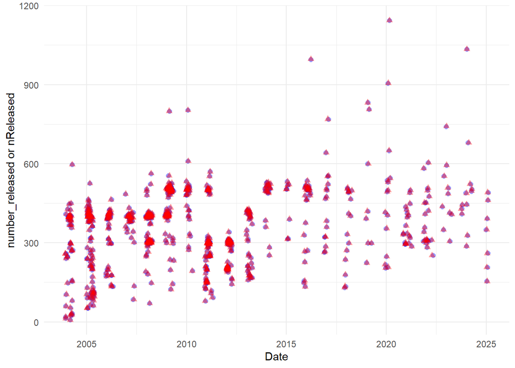

Random pick of data entry to compare between db and EDI

- test 1

```
## Rows: 1
## Columns: 15
## $ id                          <int> 5934
## $ trap_location_id            <int> 2
## $ release_id                  <chr> "BAT356"
## $ date_released               <dttm> 2022-02-10
## $ run_id                      <int> 6
## $ median_fork_length_released <dbl> 45
## $ lifestage_id                <int> NA
## $ origin_id                   <int> 3
## $ number_released             <dbl> 422
## $ updated_at                  <dttm> 2025-07-14 09:09:06
## $ updated_by                  <chr> "AdminJPE"
## $ stream                      <chr> "battle creek"
## $ site                        <chr> "ubc"
## $ subsite                     <chr> NA
## $ source                      <chr> "DB"
```

```
## Rows: 1
## Columns: 16
## $ release_id                  <chr> "BAT356"
## $ date_released               <date> 2022-02-10
## $ time_released               <time> 17:35:00
## $ release_site                <chr> NA
## $ site                        <chr> "upper battle creek"
## $ number_released             <dbl> 422
## $ median_fork_length_released <dbl> 45
## $ days_held_post_mark         <dbl> 1
## $ day_or_night_release        <chr> "night"
## $ release_temp                <dbl> 53.3
## $ release_flow                <dbl> 318
## $ release_turbidity           <dbl> 2.05
## $ origin_released             <chr> NA
## $ stream                      <chr> "battle clear creek"
## $ date                        <date> 2022-02-10
## $ source                      <chr> "EDI"
```

- test 2

```
## Rows: 1
## Columns: 15
## $ id                          <int> 5607
## $ trap_location_id            <int> 14
## $ release_id                  <chr> "CLR497"
## $ date_released               <dttm> 2011-01-12
## $ run_id                      <int> 6
## $ median_fork_length_released <dbl> 37
## $ lifestage_id                <int> NA
## $ origin_id                   <int> 3
## $ number_released             <dbl> 299
## $ updated_at                  <dttm> 2025-07-14 09:09:06
## $ updated_by                  <chr> "AdminJPE"
## $ stream                      <chr> "clear creek"
## $ site                        <chr> "lcc"
## $ subsite                     <chr> NA
## $ source                      <chr> "DB"
```

```
## Rows: 1
## Columns: 16
## $ release_id                  <chr> "CLR497"
## $ date_released               <date> 2011-01-12
## $ time_released               <time> 18:10:00
## $ release_site                <chr> "vulture bar"
## $ site                        <chr> "lower clear creek"
## $ number_released             <dbl> 299
## $ median_fork_length_released <dbl> 37
## $ days_held_post_mark         <dbl> 1
## $ day_or_night_release        <chr> "night"
## $ release_temp                <dbl> 46.4
## $ release_flow                <dbl> 265
## $ release_turbidity           <dbl> NA
## $ origin_released             <chr> NA
## $ stream                      <chr> "battle clear creek"
## $ date                        <date> 2011-01-12
## $ source                      <chr> "EDI"
```

- test 3

```
## Rows: 1
## Columns: 15
## $ id                          <int> 5966
## $ trap_location_id            <int> 2
## $ release_id                  <chr> "BAT372"
## $ date_released               <dttm> 2025-01-28
## $ run_id                      <int> 6
## $ median_fork_length_released <dbl> NA
## $ lifestage_id                <int> NA
## $ origin_id                   <int> 3
## $ number_released             <dbl> 461
## $ updated_at                  <dttm> 2025-07-14 09:09:06
## $ updated_by                  <chr> "AdminJPE"
## $ stream                      <chr> "battle creek"
## $ site                        <chr> "ubc"
## $ subsite                     <chr> NA
## $ source                      <chr> "DB"
```

```
## Rows: 1
## Columns: 16
## $ release_id                  <chr> "BAT372"
## $ date_released               <date> 2025-01-28
## $ time_released               <time> NA
## $ release_site                <chr> NA
## $ site                        <chr> "upper battle creek"
## $ number_released             <dbl> 461
## $ median_fork_length_released <dbl> NA
## $ days_held_post_mark         <dbl> NA
## $ day_or_night_release        <chr> "night"
## $ release_temp                <dbl> 56.7
## $ release_flow                <dbl> NA
## $ release_turbidity           <dbl> NA
## $ origin_released             <chr> NA
## $ stream                      <chr> "battle clear creek"
## $ date                        <date> 2025-01-28
## $ source                      <chr> "EDI"
```